# Reproducible Research Peer Assessment 1

Monali Mujumdar

December 19, 2015

This document describes some analysis done using a personal activity monitoring device. The data used for the assignment is the ‘Activity Monitoring Data’ downloaded from the Coursera website. The dataset contains the number of steps taken daily in 5-minute interval for a 2-month period. There are three columns: Steps, Date, and Interval.

### Q1. What is mean total number of steps taken per day?

The following code loads the data into a data frame ‘activity_table’, calculates the number of steps taken each day, and then plots its histogram. It also computes the mean and median of the number of steps.

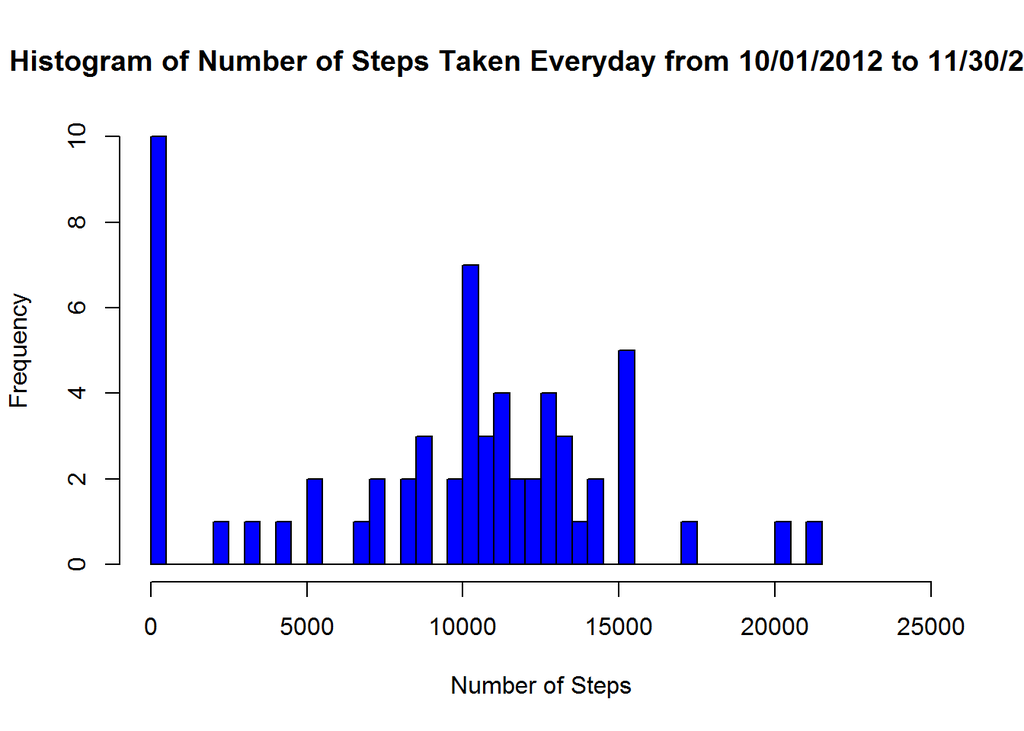

```r
activity_table<-read.csv("./data/repdata-data-activity/activity.csv",header = TRUE,sep=",")
sumdat <- tapply(activity_table$steps,activity_table$date, sum, na.rm = TRUE)
hist(sumdat,breaks = 50, main="Histogram of Number of Steps Taken Everyday from 10/01/2012 to 11/30/2012",
      xlab="Number of Steps",xlim=c(0,25000),col="blue")
```

```r
meanSteps = round(mean(sumdat),2)
medianSteps = median(sumdat)
```

The mean of number of steps is 9354.23 and median is 10395.

### Q2. What is the average daily activity pattern?

The following code computes the average of the number of steps taken in each 5-min interval across all days.

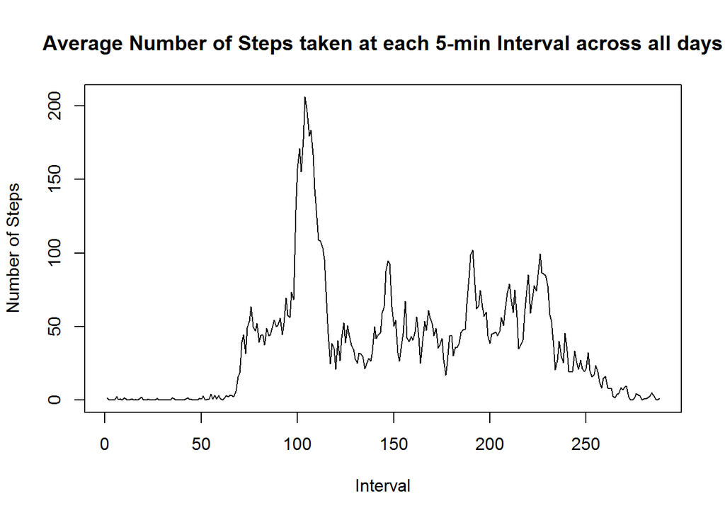

```r
Interval_number=rep(c(1:288),61) ##creates a vector of interval numbers (from 1 to 288) for each day.

activity_table<-cbind(activity_table,"Interval Number" =Interval_number) ##appends the vector to the data frame

avg_step_per_interval<-tapply(activity_table$steps,activity_table$`Interval Number`,mean,na.rm=TRUE) ##computes the mean of number of steps for each interval

interval=c(1:288) #used for plotting only
plot(interval,avg_step_per_interval,type="l",main="Average Number of Steps taken at each 5-min Interval across all days",
     xlab="Interval",ylab="Number of Steps")
```

```r
xind<-which.max(avg_step_per_interval) ##index of the interval with max number of steps
```

The 104th interval has the maximum number of steps 206.17

### Q3. Inputting missing values

```r
numNA<- sum(is.na(activity_table$steps))
```

There are 2304 NA values in the ‘Steps’ column of the dataset.

The following code replaces the missing values (NAs)by the mean of the number of steps for that interval

```r
activity_table<-cbind("Modified_Step"=activity_table$steps,activity_table) #creates a copy of the 'Steps' column

for( i in 1 : length(activity_table$steps)){

  if (is.na(activity_table$Modified_Step[i])){
    int_num<-activity_table$`Interval Number`[i]
    activity_table$Modified_Step[i] <- as.integer(ceiling(avg_step_per_interval[int_num]))
  }

}

modified_activity_table<-activity_table[,c(1,2,3)] #modified dataset with the missing values filled in
```

The following code compares the histogram of the modified number of steps after the missing values filled it, with that of the original number of steps. For ease of comparison, the original histogram is plotted again

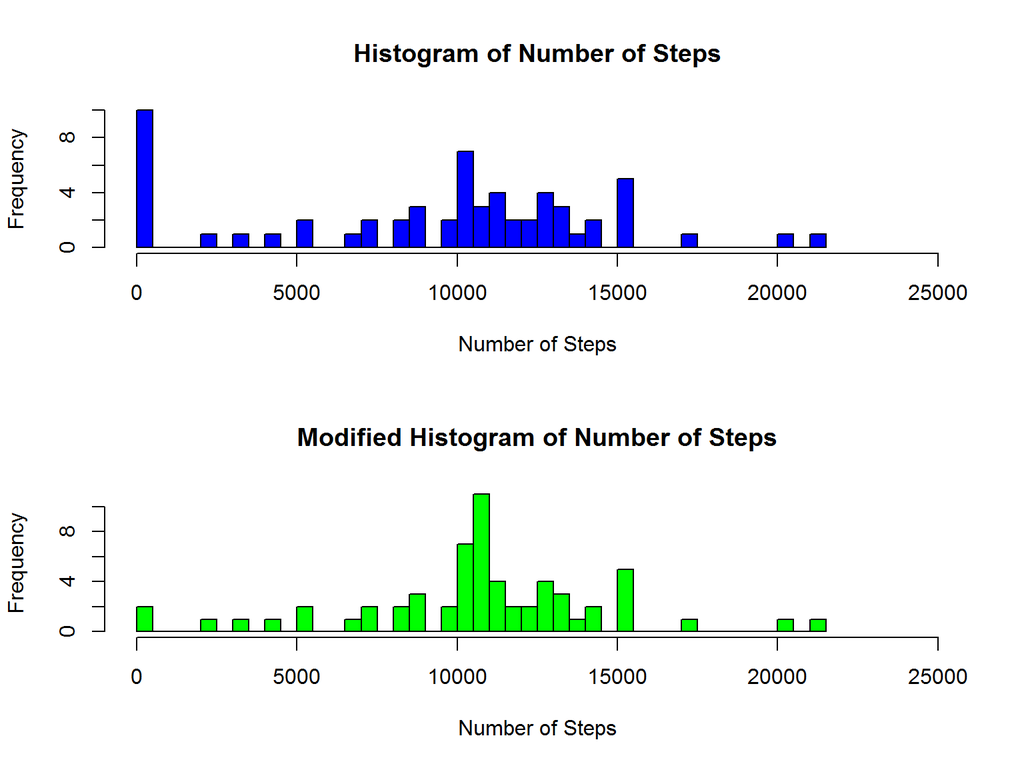

```r
sumdat_mod <- tapply(activity_table$Modified_Step,activity_table$date, sum, na.rm = TRUE)

par(mfcol=c(2,1))
hist(sumdat,breaks = 50, main="Histogram of Number of Steps",
     xlab="Number of Steps",xlim=c(0,25000),col="blue")

hist(sumdat_mod,breaks = 50, main="Modified Histogram of Number of Steps",
     xlab="Number of Steps",xlim=c(0,25000),col="green")
```

```r
meanSteps_mod = round(mean(sumdat_mod),2)
medianSteps_mod = median(sumdat_mod)
```

### Are there differences in activity patterns between weekdays and weekends?

The following code adds another factor column with ‘weekday’ and ‘weekend’ information to the dataset. The average number of steps for each interval is plotted for ‘weekend’ and ‘weekday’.

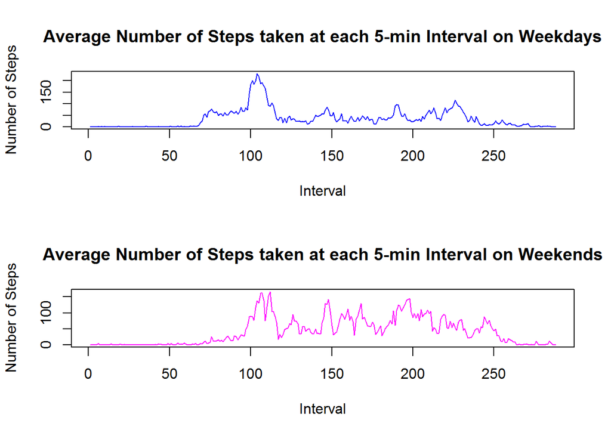

```r
daysdat<-activity_table$date
weekdaysdat<-weekdays(as.Date(daysdat,'%Y-%m-%d'))
weekdayslist <- c('Monday', 'Tuesday', 'Wednesday', 'Thursday', 'Friday')
daysstat<-factor(weekdaysdat %in% weekdayslist,
                        levels=c(FALSE, TRUE), labels=c('weekend', 'weekday'))

activity_table<-cbind("DayStat"=daysstat,activity_table)

weekend_weekday_data<-tapply(activity_table$Modified_Step,list(activity_table$`Interval Number`, activity_table$DayStat), mean)

par(mfcol=c(2,1))
plot(interval,weekend_weekday_data[,2],type="l",main="Average Number of Steps taken at each 5-min Interval on Weekdays", xlab="Interval",ylab="Number of Steps",col="blue")

plot(interval,weekend_weekday_data[,1],type="l",main="Average Number of Steps taken at each 5-min Interval on Weekends",xlab="Interval",ylab="Number of Steps",col="magenta")
```